# PulmonDB - COVID19.

Monica Padilla

## **Data pre-processing additional datasets: Desai2020 (Lung + other organs), Delorey2020 (Lung COVID) and GTEx (some tissues)**

Original sources: Delorey et al, 2021 [1], and Desai et al. 2020 [2]. In this report is also reported a re-run of experiment count matrix generation and batch correction of blanco’s data.

### **Prepare terminal**

```bash
ssh -Y mpadilla@dna.liigh.unam.mx
screen -S search
qlogin
cd /mnt/Citosina/amedina/mpadilla/COVID19/
module unload r/3.2.1
module load r/4.0.2
module load e-utilities/27abr20
umask 2
#mkdir deloney2021
cd Data/deloney2021
```

### **Search and Retrieve data**

#### **Search Data**

We need RNA-seq Lung samples with controls and infected with SARS-CoV-2 or from patients with COVID-19.

at web geo datasets: `(rna-seq[All Fields] AND ("lung"[MeSH Terms] OR lung[All Fields]) AND (covid[All Fields] OR ("Severe acute respiratory syndrome coronavirus 2"[Organism] OR ("Severe acute respiratory syndrome coronavirus 2"[Organism] OR sars-cov-2[All Fields]))) NOT scRNA-seq[All Fields]) AND "Homo sapiens"[orgn]`

```bash
einfo -dbs # view dbs, gds = geo data sets
einfo -db gds -fields # search db specific fields
esearch -db gds -query "rna-seq[ALL] AND (\"lung\"[MESH] OR lung[ALL]) AND (covid[ALL] OR \"Severe acute respiratory syndrome coronavirus 2\"[ALL] OR sars-cov-2[ALL])) AND \"Homo sapiens\"[ORGN]" | efetch -format uid | esummary -db gds | perl -pe 's/\n/,/g'


esearch -db gds -query "rna-seq[ALL] AND (covid[ALL] OR \"Severe acute respiratory syndrome coronavirus 2\"[ALL] OR sars-cov-2[ALL])) AND \"Homo sapiens\"[ORGN] NOT (scRNA-seq[ALL] OR \"single-cell RNA-seq\"[ALL])"
```

*resulting UIDs are shown below but were also saved at `uid_gds_lungSC2rnaseq.txt`

```bash
esummary -db gds -id 200176393,200167403,200167402,200176201,200182297,200181827,200179184,200157490,200178824,200151513,200164013,200163529,200162911,200171668,200155223,200167131,200163547,200161934,200157344,200161262,200161382,200155518,200160351,200158127,200152586,200159191,200155286,200156988,200154613,200151161,200147903,200150819,200150316,200148829,305471867,305471866,305471865,305471864,305471863,305471862,305471861,305471860,305471859,304796155,304796154,304796153,304796152,304796119,304796118,304796117,304796116,304796115,304796114,304796113,304766939,304766938,305230128,305230124,305230121,305230115,305230114,305230059,305230057,305230044,305230040,305230037,305230031,305230030,305229975,305229973,305230112,305230111,305230110,305230107,305230106,305230098,305230092,305230091,305230090,305230087,305230085,305230080,305230075,305230068,305230066,305230064,305230063,305230028,305230027,305230026,305230023,305230022,305230014,305230008,305230007,305230006,305230003,305230001,305229996,305229991,305229984,305229982,305229980,305229979,304822344,304822347,304822346,304822345,304698499,304698498,304698497,304698496,304698495,304698494,304698493,304698492,304698491,304698490,304698489,304698488,304698487 > esummary_gds_lungSC2rnaseq.xml
```

Saved file located at = `mpadilla/COVID19/Data/deloney2021/metadata/esummary_gds_lungSC2rnaseq.xml`

#### **Data selected**

- GSE171668, that comes from this publication [COVID-19 tissue atlases reveal SARS-CoV-2 pathology and cellular targets](https://www.nature.com/articles/s41586-021-03570-8) by Toni M Delorey, …, Aviv Regev; April 2021.
- GSE150316, also has raw data available: SRP261138, PRJNA631753. That comes from this publication [Temporal and spatial heterogeneity of host response to SARS-CoV-2 pulmonary infection.](https://www.nature.com/articles/s41467-020-20139-7) by Desai N et al, 2020.

#### **Data retrieval:GSE171668 - delorey2021**

Changed r version in cluster:

```bash
module load r/3.6.1
```

Use GEOquery:

```r
library(GEOquery)
gse <- getGEO("GSE171668", destdir = ".")
# supp <- getGEOSuppFiles("GSE171668", fetch_files = TRUE, baseDir = ".") # i didnt run this bc i didnt want all suppfiles
```

downloaded files are in = `delorey2021/GEOquery/`

Get bulk counts and metadata:

```bash
mkdir counts
mkdir metadata
cd metadata
wget https://ftp.ncbi.nlm.nih.gov/geo/series/GSE171nnn/GSE171668/suppl/GSE171668_bulk_metadata.csv.gz
cd ../counts
wget https://ftp.ncbi.nlm.nih.gov/geo/series/GSE171nnn/GSE171668/suppl/GSE171668_rsem.genes.counts.matrix.txt.gz
```

Checking that samples correspond to bulk samples:

```bash
# next file has the sample name of the counts matrix
head -n1 GSE171668_rsem.genes.counts.matrix.txt | perl -pe 's/\s/\n/g' | sort | sed 1d > GSE171668_rsem_samples.txt
# next file has bulk samples names
cut -d, -f1 ../metadata/GSE171668_bulk_metadata.csv | sort | head -n20 | perl -pe 's/-/_/g' > bulk_samples.txt
# report identical files
diff -s GSE171668_rsem_samples.txt bulk_samples.txt
```

`Files GSE171668_rsem_samples.txt and bulk_samples.txt are identical`

#### **Data retrieval: SRP261138 - desai2020**

Metadata was manually downloaded from [SRA Run Selector](https://www.ncbi.nlm.nih.gov/Traces/study/?acc=PRJNA631753&o=acc_s%3Aa) and lives here: `mpadilla/COVID19/Data/desai2020/metadata/SraRunTable_SRP261138_desai2020.txt`

The below `fastq-dump` arguments were selected with guidance of this [manual](https://edwards.sdsu.edu/research/fastq-dump/).

`fastq-dump` automatically stores cache in `~` dir, which ended up consuming all my home space and I got the `disk quota exceeded`. To disable this option I did the following:

```bash
qlogin
module load sra/2.9.6-1
vdb-config -i
```

That opens an interface, press `2` (disable local file caching) > `6` (save) > `7` (exit).

Code below was run in sge file `mpadilla/COVID19/Data/desai2020/fastq/fastqdump.sge`.

```bash
module load e-utilities/27abr20
module load sra/2.9.6-1

# Get SRR accessions, then download fastq files
esearch -db sra -query "SRP261138" |  efetch -format docsum | xtract -pattern Runs -ACC @acc  -element "&ACC" | xargs fastq-dump --outdir . --gzip --skip-technical --read-filter pass --dumpbase --split-files
```

job log file = `less fastqdump.o192951`

SOme files were missing, run with `fastqdump2.sge`

```bash
fastq-dump --outdir . --gzip --skip-technical --read-filter pass --dumpbase --split-files SRR11772358
fastq-dump --outdir . --gzip --skip-technical --read-filter pass --dumpbase --split-files SRR11772359
fastq-dump --outdir . --gzip --skip-technical --read-filter pass --dumpbase --split-files SRR11772360
fastq-dump --outdir . --gzip --skip-technical --read-filter pass --dumpbase --split-files SRR11772361
fastq-dump --outdir . --gzip --skip-technical --read-filter pass --dumpbase --split-files SRR11772362
fastq-dump --outdir . --gzip --skip-technical --read-filter pass --dumpbase --split-files SRR11772363
fastq-dump --outdir . --gzip --skip-technical --read-filter pass --dumpbase --split-files SRR11772364
fastq-dump --outdir . --gzip --skip-technical --read-filter pass --dumpbase --split-files SRR11772365
fastq-dump --outdir . --gzip --skip-technical --read-filter pass --dumpbase --split-files SRR11772366
fastq-dump --outdir . --gzip --skip-technical --read-filter pass --dumpbase --split-files SRR11772367
fastq-dump --outdir . --gzip --skip-technical --read-filter pass --dumpbase --split-files SRR12340064
```

#### **Data retrieval: GTEx v8 RNA-seq**

Datasets retrieved from: https://gtexportal.org/home/datasets

##### **RNA-seq transcript TPM counts**

Gene quantification done with RSEM, as reported here: https://www.gtexportal.org/home/documentationPage#staticTextAnalysisMethods

```bash
wget https://storage.googleapis.com/gtex_analysis_v8/rna_seq_data/GTEx_Analysis_2017-06-05_v8_RSEMv1.3.0_transcript_tpm.gct.gz
```

location: `/mnt/Citosina/amedina/mpadilla/resources/gtex/data_v8/GTEx_Analysis_2017-06-05_v8_RSEMv1.3.0_transcript_tpm.gct.gz`

##### **Sample annotation**

```bash
wget https://storage.googleapis.com/gtex_analysis_v8/annotations/GTEx_Analysis_v8_Annotations_SampleAttributesDS.txt
```

location: `/mnt/Citosina/amedina/mpadilla/resources/gtex/data_v8/GTEx_Analysis_v8_Annotations_SampleAttributesDS.txt`

##### **GENCODE v26 annotation**

```bash
wget https://storage.googleapis.com/gtex_analysis_v8/reference/gencode.v26.GRCh38.genes.gtf
```

### **Data pre-processing**

#### **Delorey 2021**

##### **Batch note**

Delorey’s dataset bulk RNA-seq samples all have the same batch, i.e. samples were prepared the same way, the same library preparation and sequenced in the same day. Thus, no within dataset correction is necessary.

##### **Normalization to CPMs**

**Count per Million CPM**

For each sample:

1. Sum counts for all genes
2. Divide genes_counts by sum
3. Multiply genes by 10^6

```r
# Load data of delorey 2021
del <- as.data.frame(read.csv("/mnt/Citosina/amedina/mpadilla/COVID19/Data/delorey2021/counts/GSE171668_rsem.genes.counts.matrix.txt", sep = "\t"))
dim(del) # 23686    20

del <- as.matrix(del)

# 1
sum.counts.samp <- apply(del,2,sum)
del.cpm <- t((t(del)/sum.counts.samp) * 10^6) # it is the same
```

##### **Filter samples for Lung**

**Select relevant samples : Lung COVID-19 biopsies**

Taken and adapted from: https://github.com/klarman-cell-observatory/covid19-autopsy/blob/main/LungBulk/deconvolution_of_lung_bulk_samples.R

```r
meta.del <- read.csv("/mnt/Citosina/amedina/mpadilla/COVID19/Data/delorey2021/metadata/GSE171668_bulk_metadata-sub.csv", sep = ",")

# Samples that were present in the input data but are not part of bulk lung samples
#                     D6:brain              D3:heart              D10:Lung
exclude.samples <- c("X02_P334354_S106_R01","X02_P166169_S027_R01","X04_P054921_S029_R01")
# D3 and D6 have 3 lung samples c("02-P166169-S038-R01","02-P334354-S088-R01","02-P334354-S066-R01")
# but these were not excluded in their deconvolution analysis as shown in the link
exclude.samples.donor <- c("D6","D3")

# Remove samples not used here from the bulk
del <- del[,!(colnames(del) %in% exclude.samples)]
dim(del) #  23686    17

# Write file with only bulk lung samples
write.table(x = del,
            file = "/mnt/Citosina/amedina/mpadilla/COVID19/Data/delorey2021/counts/GSE171668-Lung_rsem.genes.cpm_counts.matrix.csv",
            sep = ",", eol = "\n", na = "NA", row.names = T, col.names = T, quote = F)
```

##### **Convert gene_names to ENST**

This step is necessary to perform batch correction between datasets with a different gene definition and notation.

Convert gene names of Delorey to ENST ids, where the ENST ids to synonyms are the ones that were chosen as “best” previously, with Desai’s and Blanco’s transcripts, since these are expected to be ones assesed by other alignment programs.

```r
# Load data of delorey 2021
del <- as.data.frame(read.csv("/mnt/Citosina/amedina/mpadilla/COVID19/Data/delorey2021/counts/GSE171668-Lung_rsem.genes.cpm_counts.matrix.csv", sep = ","))

## 1. load table of conversion between enstids, ensgids and gene names after filtering for best trxs
# load script with matrix summarizing functions
source("/mnt/Citosina/amedina/mpadilla/COVID19/scripts/MakeExperimentCountMatrixes.R")

## Table of conversion

# ensembl_ids that result from running kallisto with gencode transcripts
ensembl_ids.kall <- read.csv("/mnt/Citosina/amedina/mpadilla/COVID19/Data/blanco2020/counts3/ensembl_ids.txt", header = F, sep = "|") # 106,143 transcripts
# gencode adds a series of annotations
colnames(ensembl_ids.kall) <- c("ensembl_transcript_id_version","ensembl_gene_id_version",
                                "havana_gene_id", "havana_transcript_id",
                                "transcript_name","gene_name",c(7:11))

# conversion table of ENST ENSG and gene names from Desai's count matrix
res.des <- Id2GeneName(ensembl_ids.kall$ensembl_transcript_id_version,
                   filter_transcripts = T, gencode_filter = T, get_gene_ids = T)

## 2. Check which genes of delorey's notation also appear in kallisto run
genes2change <- res.des$external_gene_name %in% rownames(del)
res.des <- res.des[genes2change,]
order <- match(rownames(del),res.des$external_gene_name)
res.des <- res.des[order,]

#  change their names to enstids
genes2changedel <- match(na.omit(res.des$external_gene_name), rownames(del))
del.enst <- del[genes2changedel,]
del.genename <- setdiff(del, del.enst)
rownames(del.enst) <- res.des$target_id[genes2changedel]

## for those not found, just keep the gene name. conversion of common genes was necessary for accurate comparison
del.all <- union(del.enst,del.genename)

## save matrix with conversion of gene names to enstids
write.table(x = del.all,
            file = "/mnt/Citosina/amedina/mpadilla/COVID19/Data/delorey2021/counts/GSE171668-Lung_rsem.enst-genes.cpm_counts.matrix.csv",
            sep = ",", eol = "\n", na = "NA", row.names = T, col.names = T, quote = F)
```

#### **Desai 2020**

Repeat the whole data processing done with Blanco’s dataset.

##### **Make Fastqcs**

```bash
umask 2
mkdir fastqc
ls fastq/ > fastqc/makefastqc.sge
cd fastqc
perl -pe 's/^/fastqc ..\//' makefastqc.sge | perl -pe 's/fastq\.gz/fastq\.gz -f fastq -o . -d \.\/tmp/' > fastqc.sge
qsub fastqc.sge
```

##### **Trimming**

```bash
mkdir trimmed
module load trimmomatic/0.33
for file in ../fastq/*1.fastq.gz; do trimmomatic PE -phred33 -basein $file -baseout ${file//_1.fastq/_trmd_1.fastq} ILLUMINACLIP:/mnt/Citosina/amedina/mpadilla/resources/trimmomatic/adapters/TruSeq-SE.fa:2:30:10 SLIDINGWINDOW:5:30 MINLEN:40; done
```

Order reads

```bash
mv fastq/*trmd* trimmed/
cd trimmed
cut -d, -f1,2 ../metadata/subset_SRP261138_desai2020.csv | perl -pe 's/(SRR.*),(SAMN.*)/mkdir $2; mv $1\* $2\//'
```

##### **kallisto + gencode**

Download [GENCODE v38](https://www.gencodegenes.org/human/) ref transcriptome :

```bash
### reference Protein-coding transcript sequences
### gencode.v38.pc_transcripts.fa.gz
wget https://ftp.ebi.ac.uk/pub/databases/gencode/Gencode_human/release_38/gencode.v38.pc_transcripts.fa.gz
```

Annotation references:

- EMBL
- CCDS : [Consensus Coding Sequence Project](https://www.ncbi.nlm.nih.gov/projects/CCDS/CcdsBrowse.cgi)
- RefSeq_dna, _peptide
- Uniprot
- SWISSPROT

Make gencode transcriptome index for kalisto :

```bash
### index_kallisto45_gencode38_hsapiens_cds
kallisto index -i ./kallisto/index_kallisto45_gencode38_hsapiens_cds gencode/v38/gencode.v38.pc_transcripts.fa.gz
```

To make sge file with `kallisto quant` command, I did:

dir = `/mnt/Citosina/amedina/mpadilla/COVID19/Data/desai2020/kallisto_gen/`

```bash
cut -d, -f1,2 ../metadata/subset_SRP261138_desai2020.csv | perl -pe 's/.*,(SAMN.*)/mkdir $1; kallisto quant -i \/mnt\/Citosina\/amedina\/mpadilla\/resources\/kallisto\/index_kallisto45_gencode38_hsapiens_cds -o $1 ..\/trimmed\/$1\/\*P.fastq.gz/' > kquant_gen.sge
```

The pipeline below shows how `kallisto quant` was run.

```bash
mkdir kallisto
module load kallisto/0.45.0
mkdir sample
kallisto quant -i /mnt/Citosina/amedina/mpadilla/resources/kallisto/index_kallisto45_ensemblv102_hsapiens_cdna -o sample ../trimmed/sample/*P.fastq.gz
```

`abundance.tsv` files contain counts for `106143` (protein coding) transcripts.

##### **Gene annotation gencodev38**

To reduce the number of transcripts to approx 1 per gene, we used GENCODE’s gene basic annotation for protein coding transcripts.

The table with ensembl ENSG ids, ENT ids and corresponding gene names are located in = `/mnt/Citosina/amedina/mpadilla/resources/gencode/v38/fltr_transcripts/gencode.v38.basic.pc.transcripts.ensgid_enstid_genename.csv`

This file has `61067` transcripts.

Some genes still have many transcripts as shown below.

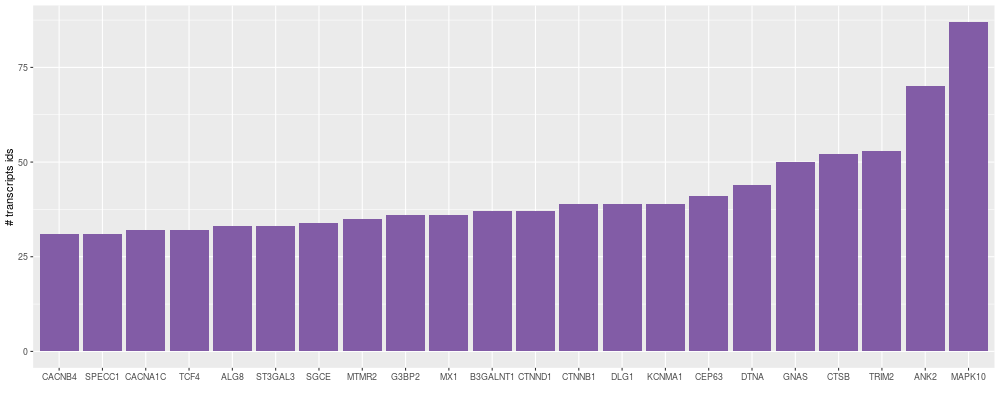

```r
counts <- read.csv("transcript_enstids_counts.csv", header = T, sep = ",")
mt30 <- which(counts$count_enst_ids > 30) # more than 30 transcripts
png(file = "./transcript_enstids_30counts.png", width = 1000, height = 400)
counts %>%
  mutate(name = fct_reorder(gene_name, count_enst_ids)) %>%
  slice(1:22) %>%
  ggplot(aes(x=name, y=count_enst_ids)) +
  geom_col(fill="#825CA6") +
  labs(x="", y="# transcripts ids")
dev.off()
```

For the `13626` genes that have more than one transcript assigned, we try to select for the best one with trasncript flags as before.

##### **TPM Count matrix all transcripts, Blanco - Desai**

TPMs, also dont filter genes:

For Blanco’s data:

```r
library(tidyverse)

# get file paths of count matrixes from blanco2020 and desai2020
bla.samples.dirs <- str_subset(str_subset(list.dirs("."), "counts3"), "/.+/.+/.+/.+")
bla.samples.dirs <- str_subset(bla.samples.dirs, "Ferret", negate=T)
bla.files <- paste0(bla.samples.dirs, "/abundance.tsv")

# regex to identy sample names
sample_regex <- "[SAMNG]{3,4}\\d+"

# Join all samples counts into one matrix
source("/mnt/Citosina/amedina/mpadilla/COVID19/scripts/MakeExperimentCountMatrixes.R") # code make experiment count matrix

# blanco
MakeExpCountsMatrix(files = bla.files, outfile_name = "blanco2020/counts3/blanco2020-counts_gencv38-alltrxs.csv",
                    sample_regex = sample_regex, filter_transcripts = F,
                    host_ensembl = "https://may2021.archive.ensembl.org",
                    gencode_filter = F, output_matrix_transcripts_ids = T,
                    use_gencode = T)
```

For Desai’s data:

```r
des.samples.dirs <- str_subset(str_subset(list.dirs("."), "kallisto_gen"), "/.+/.+/.+")
des.files <- paste0(des.samples.dirs, "/abundance.tsv")

# desai
MakeExpCountsMatrix(files = des.files, outfile_name = "desai2020/kallisto_genc/desai2020-counts-alltrxs.csv",
                    sample_regex = sample_regex, filter_transcripts = F,
                    host_ensembl = "https://may2021.archive.ensembl.org",
                    gencode_filter = F, output_matrix_transcripts_ids = T,
                    use_gencode = T)
```

##### **Batch Correction on Blanco - Desai TPM matrix all trxs**

**Define batches and run combat-seq**

###### **Per Dataset (dates and platform)**

**For Blanco’s data**

```r
# Load blanco's experiment count matrix
blanco <- as.data.frame(read.csv("blanco2020/counts3/blanco2020-counts_gencv38-alltrxs_trxs.csv", sep = ","))
dim(blanco) #    78 106143
# Load metadata
meta <- as.data.frame(read.csv("/mnt/Citosina/amedina/mpadilla/COVID19/Data/multi-datasets/metadata/date_sample_source-Human.tsv", sep = "\t"))
colnames(meta) <- c("date","sample","source")

# Filter for Blanco's data
meta.bla <- str_detect(meta$sample, "^GSM")
meta.bla <- meta[meta.bla,]

# Put metadata in the same order
index <- match(rownames(blanco), meta.bla$sample)
meta.bla <- meta.bla[index,]

# Define batches (in this case by date)
dates <- unique(meta.bla$date)
batch <- meta.bla$date
for (i in 1:length(dates)) {
  batch <- str_replace(batch, dates[i], paste0(i))
  i = i + 1
}
batch <- as.numeric(batch)

# Define bio condition (co variate), to preserve signal in adj data
exp <- rev(unique(meta.bla$source)) # rev order so that it doesnt match other experiments
bio.cond <- meta.bla$source
for (i in 1:length(exp)) {
  bio.cond <- str_replace(bio.cond, exp[i], paste0(i))
  i = i + 1
}
bio.cond <- as.numeric(bio.cond)

# transpose and turn to matrix
blanco <- t(as.matrix(blanco)) # combat seq requires rows genes

# Correction of batch effects with ComBat-seq
library(sva)
adj.bla <- ComBat_seq(blanco, batch = batch, group = bio.cond)
```

Check created object

```r
class(adj.bla) # "matrix" "array"
# adj.bla <- adj.bla[which(apply(adj.bla,1,var) != 0),] # quit counts that transform to 0
dim(adj.bla) # 106143     78
object.size(adj.bla)/1e6 # 75.6 MB
```

*Note:* Object saved as and can be loaded as following.

```r
# write.csv(adj.bla, file = "blanco2020/counts3/blanco2020-counts_gencv38-alltrxs_trxs-adj.csv", quote = F)
```

**For Desai’s data**

```r
# Load desai's experiment count matrix
desai <- as.data.frame(read.csv("desai2020/kallisto_gen/desai2020-counts-alltrxs_trxs.csv", sep = ","))
dim(desai)
# Load metadata
meta <- as.data.frame(read.csv("/mnt/Citosina/amedina/mpadilla/COVID19/Data/multi-datasets/metadata/date_sample_source-Human.tsv", sep = "\t"))
colnames(meta) <- c("date","sample","source")

# Filter for Blanco's data
meta.des <- str_detect(meta$sample, "^SAMN")
meta.des <- meta[meta.des,]

# Put metadata in the same order
index <- match(rownames(desai), meta.des$sample)
meta.des <- meta.des[index,]

# tag lung controls of desai 2020
lung.control.d20 <- meta.des$sample %in% c("SAMN14891157","SAMN14891156","SAMN14891155","SAMN14891154","SAMN14891153")
meta.des$source[lung.control.d20] <- "lung_healthy_d20"

# Define batches (in this case by date)
dates <- unique(meta.des$date)
batch <- meta.des$date
for (i in 1:length(dates)) {
  batch <- str_replace(batch, dates[i], paste0(i))
  i = i + 1
}
batch <- as.numeric(batch)

# there's also a batch taking the platform used into account (all other samples were done using nextseq 500)
illumina.miseq <- c("SAMN15660687","SAMN15660692","SAMN15660698")
miseq.samples <- which(rownames(desai) %in% illumina.miseq)
batch[miseq.samples] <- 3 # add batch

# Define bio condition (co variate), to preserve signal in adj data
exp <- rev(unique(meta.des$source)) # rev order so that it doesnt match other experiments
bio.cond <- meta.des$source
for (i in 1:length(exp)) {
  bio.cond <- str_replace(bio.cond, exp[i], paste0(i))
  i = i + 1
}
bio.cond <- as.numeric(bio.cond)

# transpose and turn to matrix
desai <- t(as.matrix(desai)) # combat seq requires rows genes

# Correction of batch effects with ComBat-seq
library(sva)
adj.des <- ComBat_seq(desai, batch = batch, group = bio.cond)
```

```
Found 3 batches
Using full model in ComBat-seq.
Adjusting for 10 covariate(s) or covariate level(s)
Estimating dispersions
Fitting the GLM model
Shrinkage off - using GLM estimates for parameters
Adjusting the data
```

Check created object

```r
class(adj.des) # "matrix" "array"
# adj.des <- adj.des[which(apply(adj.des,1,var) != 0),] # quit counts that transform to 0
dim(adj.des) # 106143     88
object.size(adj.des)/1e6 # 84.1 MB
```

*Note:* Object saved as and can be loaded as following.

```r
# write.csv(adj.des, file = "desai2020/kallisto_gen/desai2020-counts-alltrxs-adj.csv", quote = F)
```

###### **Second Correction: between datasets**

```r
## adj.bla, adj.des
## Join adjusted counts from each
adj.bla.g <- rownames_to_column(as.data.frame(adj.bla), var = "trx_id")
adj.des.g <- rownames_to_column(as.data.frame(adj.des), var = "trx_id")
adj.both <- full_join(adj.bla.g, adj.des.g, by = "trx_id")
adj.both <- column_to_rownames(adj.both, var = "trx_id")
adj.both <- as.matrix(adj.both)

# subset for blades samples
meta.bla <- str_detect(meta$sample, "^GSM")
meta.des <- str_detect(meta$sample, "^SAMN")
meta <- meta[meta.bla | meta.des,]

# Put metadata in the same order
index <- match(colnames(adj.both), meta$sample)
meta <- meta[index,]

# Define batches (in this case by origin of dataset)
samp.bla <- which(str_detect(meta$sample, "^GSM"))
samp.des <- which(str_detect(meta$sample, "^SAMN"))
batch <- rep(0,length(meta$sample))
batch[samp.bla] <- 1 # blanco batch
batch[samp.des] <- 2 # desai batch

# tag lung controls of desai 2020
lung.control.d20 <- meta$sample %in% c("SAMN14891157","SAMN14891156","SAMN14891155","SAMN14891154","SAMN14891153")
meta$source[lung.control.d20] <- "Lung_Healthy"
# tag equally lung covid samples across datasets
lung.covid <- c("lung","Lung_sample_from_postmortem_COVID-19_patient")
lung.covid.samples <- which(meta$source %in% lung.covid)
meta$source[lung.covid.samples] <- "Lung_COVID"
# tag equally lung healthy samples across datasets
lung.control <- c("Lung_Healthy","Lung_biopsy_for_heatly_negative_control")
lung.control.samples <- which(meta$source %in% lung.control)
meta$source[lung.control.samples] <- "Lung_Healthy"

# Define bio condition (co variate), to preserve signal in adj data
exp <- rev(unique(meta$source)) # rev order so that it doesnt match other experiments
bio.cond <- meta$source
for (i in 1:length(exp)) {
  bio.cond <- str_replace(bio.cond, exp[i], paste0(i))
  i = i + 1
}
bio.cond <- as.numeric(bio.cond)

# Correction of batch effects with ComBat-seq
library(sva)
adj.both <- ComBat_seq(adj.both, batch = batch, group = bio.cond)
```

```
Found 2 batches
Using full model in ComBat-seq.
Adjusting for 25 covariate(s) or covariate level(s)
Estimating dispersions
```

Check created object

```r
class(adj.both) # "matrix" "array"
# adj.des <- adj.des[which(apply(adj.des,1,var) != 0),] # quit counts that transform to 0
dim(adj.both) # 106143    166
object.size(adj.both)/1e6 # 150.9 MB
```

*Note:* Object saved as and can be loaded as following.

```r
# write.csv(adj.both, file = "multi-datasets/counts/blanco2020-desai2020-mer-adj-counts-alltrxs-adj.csv", quote = F)
```

#### **GTEx v8 RNA-seq**

##### **Subset for data of interest**

Applied filters and criteria:

- RNA-seq data
- Tissues of interest:
- Bowel (intestine) = `Small Intestine - Terminal Ileum`
- Kidney = `Kidney - Cortex`, !`Kidney - Medulla` because onlu miRNA data
- Liver = `Liver`
- Lung = `Lung`
- Heart = `Heart - Left Ventricle`, `Heart - Atrial Appendage`
- Batch repetition within and across tissues, to correct for that effect
- Good reported quality

Filter sample annotation by experiment (rnaseq) and tissues:

```r
library(dplyr)

# read sample annotation file
meta <- as.data.frame(read.csv("GTEx_Analysis_v8_Annotations_SampleAttributesDS.txt", sep = "\t"))

# filter by experiment type of interest (mrna rnaseq)
#        and by tissues of interest
meta <- meta %>%
  select(SAMPID, SMTS, SMTSD, SMNABTCH, SMNABTCHT , SMGEBTCH, SMGEBTCHT, SMAFRZE) %>%
  filter(SMNABTCHT == "RNA Extraction from Paxgene-derived Lysate Plate Based",
         SMAFRZE == "RNASEQ", SMGEBTCHT == "TruSeq.v1",
         SMTS == "Heart" | SMTS == "Lung" | SMTS == "Small Intestine" | SMTS == "Liver"
         | SMTS == "Kidney" ) %>%
  select(SAMPID, SMTS, SMTSD, SMNABTCH, SMGEBTCH)
```

##### **Check which batches to use**

We want ~10 samples per tissue. Criteria for choosing them:

- Only `Heart` samples are split into two categories: `Atrial appendage` and `Left Ventricle`, choose same number of samples for each.
- Have the minimum number of batches, provided they are repeated within and across tissues.

```r
# repetition of batches
meta %>%
  group_by(SMNABTCH, SMGEBTCH) %>%
  summarize(Count=n()) %>%
  arrange(desc(Count))

# repetition of tissues and batches
batch_rep_perts <- meta %>%
  group_by(SMTS, SMNABTCH, SMGEBTCH) %>%
  summarize(Count=n()) %>%
  arrange(desc(Count)) %>%
  filter(Count > 1)

# repetition of batches between diff tissues
batch_rep_manyts <- meta %>%
  group_by(SMTS, SMNABTCH, SMGEBTCH) %>%
  summarize(Count=n()) %>%
  arrange(desc(Count)) %>%
  filter(Count > 1) %>%
  group_by(SMNABTCH, SMGEBTCH) %>%
  summarize(Count=n()) %>%
  arrange(desc(Count)) %>%
  filter(Count > 1)

# batches repeated across 3 or 4 organs
batch_rep_ts34 <- batch_rep_manyts$SMNABTCH[1:9]
# batches repeated across 2 organs
batch_rep_ts2 <- batch_rep_manyts$SMNABTCH[-c(1:9)]
```

Batches that are most repeated across diff organs (counts of organs present shown):

```
SMNABTCH SMGEBTCH   Count  +selected
   <chr>    <chr>      <int>
 1 BP-48576 LCSET-4955     4 +
 2 BP-75925 LCSET-9767     4 +
 3 BP-43881 LCSET-4793     3
 4 BP-44261 LCSET-4796     3 +
 5 BP-45390 LCSET-4633     3
 6 BP-47696 LCSET-4907     3 +
 7 BP-67833 LCSET-8132     3 +
 8 BP-69094 LCSET-8723     3
 9 BP-73249 LCSET-9410     3
10 BP-42087 LCSET-4038     2
```

Check for batches repeated across 4 or 3 tissues to start selection. If not all tissues are present in those samples (the case for Kidney and Intestine), take batches repeated across 2 tissues to complete number wanted of samples.

```r
# limiting organ is Kidney and Small Intestine, take whichever batches that are repeated in each
# Kidney
batch_rep_perts %>%
  filter(SMNABTCH %in% batch_rep_ts34) %>%
  filter(SMTS == "Kidney") # 2:BP-67833, 2:BP-75925, 2:BP-49102, 1:BP-47696, 1:BP-44261 = 8
# Bowel
batch_rep_perts %>%
  filter(SMNABTCH %in% batch_rep_ts34) %>%
  filter(SMTS == "Small Intestine")
                        # 2:BP-44261, 2:BP-48576, 2:BP-56446, 1:BP-47696, 1:BP-75925 = 8
# Liver
batch_rep_perts %>%
  filter(SMNABTCH %in% batch_rep_ts34) %>%
  filter(SMTS == "Liver") # 3:BP-75925, 2:BP-48576, 2:BP-56446, 3: BP-47696 = 10
                          # after filtering
                          # 3:BP-75925, 2:BP-48576, 2:BP-56446, 3: BP-47696 = 10
# Heart -atrial,left ventricle
meta %>%
  group_by(SMTS, SMTSD, SMNABTCH, SMGEBTCH) %>%
  filter(SMTS == "Heart") %>%
  summarize(Count=n()) %>%
  arrange(desc(Count)) %>%
  filter(Count > 1) %>%
  filter(SMNABTCH %in% batch_rep_ts34)
  # Atrial = 2: BP-67833, 4: BP-44261 = 6 | 3: BP-49102, 3: BP-47696 = 12
  # Left = 2: BP-75925, 2: BP-48576 = 4 | 2: BP-49102, 3: BP-47696 = 9

# subset for heart = 12  as follows:
  # Atrial = 1: BP-67833, 1: BP-44261 = 2 | 2: BP-49102, 2: BP-47696 = 6
  # Left = 1: BP-75925, 1: BP-48576 = 2   | 2: BP-49102, 2: BP-47696 = 6

# after filtering
# Atrial = 1: BP-67833, 4: BP-44261, 1: BP-48576 = 6 | 3: BP-49102, 3: BP-47696 = 12
  # Left = 2: BP-75925, 2: BP-48576, 1: BP-44261, 1: BP-67833 =6 | 3: BP-49102, 3: BP-47696 = 12

# filter for all  BP-48576(atrial), BP-44261(left), BP-67833(atrial),
#   3->BP-44261(atrial), 1-> BP-75925(left), 1-> BP-48576(left)
#   2-> BP-49102 (1left, 1atrial), 2-> BP-47696 (1left, 1atrial)

# Lung
batch_rep_perts %>%
  filter(SMNABTCH %in% batch_rep_ts34) %>%
  filter(SMTS == "Lung")
# batches counts:
# 3: BP-44261, 3:BP-75925, 2: BP-48576, 2:BP-67833, 2: BP-49102, 6:BP-47696 = 18

# subset for lung as follows:
# 2: BP-44261, 2:BP-75925, 2: BP-48576, 2:BP-67833, 2: BP-49102, 2:BP-47696 = 12

# after filtering
# 3: BP-44261, 3:BP-75925, 2: BP-48576, 2:BP-67833, 3: BP-49102, 6:BP-47696 = 16

# filter for all BP-56446
#     1-> BP-49102-->( LCSET-5305)
#     1-> BP-44261, 1-> BP-75925, 4->BP-47696


# to complete required sample number, take 2 from kidney and intestine
# from batches that are repeated 2 times across organs
batch_rep_perts %>%
  filter(SMNABTCH %in% batch_rep_ts2) %>%
  filter(SMTS == "Kidney") # 2:BP-49102 = 6
```

7 SMNA Batches selected = `BP-67833, BP-75925, BP-49102, BP-44261, BP-48576, BP-BP-56446, BP-47696`

8 batches in combination with SMGE batch:

```
SMNABTCH SMGEBTCH #diff.tissues
1 BP-48576 LCSET-4955 4
2 BP-75925 LCSET-9767 5
3 BP-44261 LCSET-4796 4
4 BP-47696 LCSET-4907 5
5 BP-67833 LCSET-8132 3
6 BP-56446 LCSET-6445 3
7 BP-49102 LCSET-5305 2
8 BP-49102 LCSET-5304 2
```

##### **Apply batches filters**

```r
##########
## Apply filters for all samples over a well-checked subset of batches

# SMNABTCHes chosen, repeated within and across organs
smnabatches_selected <- c("BP-67833","BP-75925","BP-49102","BP-44261",
                      "BP-48576","BP-56446","BP-47696")
# paired SMGEBTCHes
gebatches_selected <- c("LCSET-4955","LCSET-9767","LCSET-4796","LCSET-4907",
                        "LCSET-8132","LCSET-5305","LCSET-5304","LCSET-6445")

# subset for selected batches
meta <- meta %>%
  filter(SMNABTCH %in% smnabatches_selected, SMGEBTCH %in% gebatches_selected)

##########
## Apply further filter for Heart and Lung

# Filter for specific batches on certain organs
#       (the ones that were magically added after filtering for batches)
#   "BP-48576"-atrial
#   "BP-44261"-left
#   "BP-67833"-atrial
#   "BP-56446"-lung
meta <- meta %>%
  filter(
    !(
      (SMTSD == "Heart - Atrial Appendage" & SMNABTCH %in% c("BP-48576","BP-67833")) |
      (SMTSD == "Heart - Left Ventricle" & SMNABTCH == "BP-44261") |
      (SMTS == "Lung" & SMNABTCH == "BP-56446")
      )
    )
# Filter for a subset of samples from a certain batch:
# "BP-44261" 3-atrial,        1-lung +
# "BP-47696" 1-left,1-atrial  4-lung +
# "BP-48576" 1-left                  +
# "BP-49102" 1-left,1-atrial  1-lung-LCSET-5305 +
# "BP-75925" 1-left           1-lung +
exclude.samples <- meta %>%
  filter( (SMTS == "Heart" &
            SMNABTCH %in% c("BP-44261","BP-75925","BP-48576","BP-49102","BP-47696")) |
          (SMTS == "Lung" &
             SMNABTCH %in% c("BP-44261","BP-75925","BP-49102","BP-47696"))
          ) %>%
  arrange(SMNABTCH) %>%
  # took the first that met criteria for subsetting
  slice(1:3,6,8:11,13:14,20,22:23,25,31:32) %>%
  select(SAMPID)
exclude.samples <- as.array(exclude.samples$SAMPID)

meta <- filter(meta,!(SAMPID %in% exclude.samples))
##########

# Table with samples to use, with annotations of tissue and batches
write.table(x = meta,
  file = "/mnt/Citosina/amedina/mpadilla/COVID19/Data/gtex_v8-fltr/GTEx_v8_SampleAttributesDS-fltr.csv",
            sep = ",", eol = "\n", na = "NA", row.names = F, col.names = T, quote = F)
```

```
SAMPID  SMTS    SMTSD   SMNABTCH    SMGEBTCH
GTEX-145MO-2326-SM-5NQ9K    Liver   Liver   BP-47696    LCSET-4907
GTEX-146FH-1126-SM-5NQAT    Heart   Heart - Atrial Appendage    BP-47696    LCSET-4907
GTEX-146FH-1526-SM-5NQBU    Liver   Liver   BP-47696    LCSET-4907
GTEX-14753-1626-SM-5NQ9L    Liver   Liver   BP-47696    LCSET-4907
GTEX-147F3-0726-SM-5NQ9U    Lung    Lung    BP-47696    LCSET-4907
GTEX-147F4-1226-SM-5NQAY    Heart   Heart - Left Ventricle  BP-47696    LCSET-4907
GTEX-147JS-1126-SM-5RQIW    Liver   Liver   BP-48576    LCSET-4955
...
```

##### **Subset samples GTEx v8 gene count matrix**

Subset for samples of interest:

```r
librar(tidyverse)

# gtex data
gtex <- as.data.frame(read.csv("GTEx_Analysis_2017-06-05_v8_RNASeQCv1.1.9_gene_reads2.gct", sep = "\t"), header = F)
dim(gtex)
head(gtex)[,1:5]
# metadata
meta <- as.data.frame(read.csv("/mnt/Citosina/amedina/mpadilla/COVID19/Data/gtex_v8-fltr/GTEx_v8_SampleAttributesDS-fltr.csv", sep = ","))
dim(meta)

samples <- as.array(meta$SAMPID)
samples <- str_replace_all(samples, "-",".")
smpl.fltr <- colnames(gtex) %in% samples
# first two cols are ensg_id and gene_name, I am working with the latter
smpl.fltr[1] = TRUE
smpl.fltr[2] = TRUE
gtex <- gtex[,smpl.fltr]

#write that table
write.table(x = meta,
  file = "/mnt/Citosina/amedina/mpadilla/COVID19/Data/gtex_v8-fltr/GTEx_v8-RNASEQ-subTissues-counts.csv", sep = ",", eol = "\n", na = "NA", row.names = F, col.names = T, quote = F)

# Filter for unexpressed genes across tissues
# gtex_fltr <- gtex[which(apply(gtex,1,var) != 0),]
```

##### **Normalization of gene counts**

**Count per Million CPM**

For each sample:

1. Sum counts for all genes
2. Divide genes_counts by sum
3. Multiply genes by 10^6

```r
# gtex samples of interest with gene ids rownames
gtex.ensg <- column_to_rownames(gtex[,-2], var = "Name")
gtex.ensg <- as.matrix(gtex.ensg)

# 1
sum.counts.samp <- apply(gtex.ensg,2,sum)
gtex.ensg.cpm <- t((t(gtex.ensg)/sum.counts.samp) * 10^6)
```

**Transcripts per Million TPM**

1. Get A. For each gene:
- A = (sum gene_counts * 10^3)/ gene_length
2. A/sum(A) * 10^6

##### **Batch correction**

```r
# gtex samples of interest with gene ids rownames
#gtex.ensg <- column_to_rownames(gtex[,-2], var = "Name")
# gtex.ensg <- gtex.ensg.cpm

# metadata
meta <- as.data.frame(read.csv("/mnt/Citosina/amedina/mpadilla/COVID19/Data/gtex_v8-fltr/GTEx_v8_SampleAttributesDS-fltr.csv", sep = ","))
dim(meta)

# order meta as in gtex.ensg
meta$SAMPID <- str_replace_all(meta$SAMPID, "-",".") # slight diff sample notation correction
order.meta <- match(colnames(gtex.ensg), meta$SAMPID)
meta <- meta[order.meta,]

# Define batches (SMNA)
SMNA <- unique(meta$SMNABTCH)
batch <- meta$SMNABTCH
for (i in 1:length(SMNA)) {
  batch <- str_replace(batch, SMNA[i], paste0(i))
  i = i + 1
}
batch <- as.numeric(batch)
# Add GE batches combination (only two diff GE batches in BP-49102)
gebtch.49102 <- meta$SMNABTCH == "BP-49102" & meta$SMGEBTCH == "LCSET-5305"
batch[gebtch.49102] <- 8

# Define batches according to biological condition
tissue.esp <- rev(unique(meta$SMTSD))
bio.cond <- rev(meta$SMTSD)
for (i in 1:length(tissue.esp)) {
  bio.cond <- str_replace(bio.cond, tissue.esp[i], paste0(i))
  i = i + 1
}
bio.cond <- as.numeric(bio.cond)

# Correction of batch effects with ComBat-seq
gtex.ensg <- as.matrix(gtex.ensg)
library(sva)
adj.gtex <- ComBat_seq(gtex.ensg, batch = batch, group = bio.cond)
```

```
Found 8 batches
Using full model in ComBat-seq.
Adjusting for 5 covariate(s) or covariate level(s)
Estimating dispersions
Fitting the GLM model
Shrinkage off - using GLM estimates for parameters
Adjusting the data
```

Check created object

```r
class(adj.gtex) # "matrix" "array"
dim(adj.gtex) # 56200    50
object.size(adj.gtex)/1e6 # 27.4 MB
```

Not filtering for genes with zero counts because it follows a joining with desai’s genes.

*Note:* Object saved as and can be loaded as following.

```r
# write.csv(adj.gtex, file = "/mnt/Citosina/amedina/mpadilla/COVID19/Data/gtex_v8-fltr/GTEx_v8-RNASEQ-subTissues-adj-counts.csv", quote = F)
adj.gtex <- as.data.frame(read.csv("/mnt/Citosina/amedina/mpadilla/COVID19/Data/gtex_v8-fltr/GTEx_v8-RNASEQ-subTissues-adj-counts.csv", sep = ","))
```

##### **Get “best” ENST for each ENSG**

Necessary for batch correction between datasets gtex and desai. (transcripts in desai have ENST, this matrix cannot be shriked as gtex’s, but we can convert the names from gtex)

```r
ensg.gtex <- rownames(adj.gtex)

# load script with matrix summarizing functions
source("/mnt/Citosina/amedina/mpadilla/COVID19/scripts/MakeExperimentCountMatrixes.R")

## load table of conversion of all posible transcripts for all ensgs and gene names of gencode v26
gencodev26.b <- as.data.frame(read.csv(
          "/mnt/Citosina/amedina/mpadilla/resources/gencode/v26/fltr_transcripts/gencode.v26.basic.annotation.gene_id-trx_id-genename.tsv",
          header = T, sep = "\t"))
common.ensg <- which(gencodev26.b$ensembl_gene_id_version %in% ensg.gtex)
ensembl_ids <- gencodev26.b[common.ensg,"ensembl_transcript_id_version"]
all.ensg.gtex.enst <- gencodev26.b[common.ensg,] ## all posible transcripts in gtex engs ids

length(ensg.gtex %in% gencodev26.b$ensembl_gene_id_version)

## 2. Search best transcipt with Id2GeneName changed so that it searches 1 trx per ensg instead of 1trx per gene
res.gen26 <- mulENST2oneperENSG(ensembl_ids,filter_transcripts = T,
                                gencode_filter = T, get_gene_ids = T)

## Take enst from first match of the ensg id
  # format
  all.ensg.gtex.enst <- relocate(all.ensg.gtex.enst, ensembl_gene_id_version,
                                 .after = ensembl_transcript_id_version)
  colnames(all.ensg.gtex.enst) <- colnames(res.gen26)
dif <- setdiff(all.ensg.gtex.enst, res.gen26)
lacking.ensgs <- match(dif$ensembl_gene_id_version, all.ensg.gtex.enst$ensembl_gene_id_version)
rest.ensg.gtex.enst <- distinct(all.ensg.gtex.enst[lacking.ensgs,])


## 3. Join tables of conversion between ids and gene_name
ensg.gtex.enst <- union(res.gen26,rest.ensg.gtex.enst)
```

Change ENSGids for ENSTids to enable comparison between datasets:

```r
## check which ensgs to retrieve and match them
index <- match(rownames(adj.gtex), ensg.gtex.enst$ensembl_gene_id_version)
ensg.gtex.enst2 <- ensg.gtex.enst[index,]

## save the conversion matrix just in case
write.csv(ensg.gtex.enst2, file = "/mnt/Citosina/amedina/mpadilla/COVID19/Data/gtex_v8-fltr/conversion_enst_ensg_genename.csv", quote = F, row.names = F, col.names = T)

# Rename genes as their "best" enst for further comparison
rownames(adj.gtex) <- ensg.gtex.enst2$target_id
```

Write file out

```r
write.csv(adj.gtex, file = "/mnt/Citosina/amedina/mpadilla/COVID19/Data/gtex_v8-fltr/GTEx_v8-RNASEQ-subTissues-adj-counts-enst.csv", quote = F, row.names = T, col.names = T)

# adj.gtex <- as.data.frame(read.csv("/mnt/Citosina/amedina/mpadilla/COVID19/Data/gtex_v8-fltr/GTEx_v8-RNASEQ-subTissues-adj-counts-enst.csv", sep = ","))
```

##### **Filter genes**

pyscenic takes gene names as input, not ids. We need gene names but only one per gene.

```r
# Filter by ENSTs found before with function that searches best transrcipt fpr a gene name
ensembl_ids <- rownames(adj.gtex)
res <- Id2GeneName(ensembl_ids, filter_transcripts = T, gencode_filter = T, get_gene_ids = T)
dim(res)

# Format count matrix to rows gene names and cols samples
gtex <- FormatExpCountsMatrix(adj.gtex, res, filter_transcripts = T, outfile_name = "/mnt/Citosina/amedina/mpadilla/COVID19/Data/gtex_v8-fltr/GTEx_v8-RNASEQ-subTissues-adj-counts-fltrensg.csv")
# gtex <- as.data.frame(read.csv("/mnt/Citosina/amedina/mpadilla/COVID19/Data/gtex_v8-fltr/GTEx_v8-RNASEQ-subTissues-adj-counts-fltrensg.csv", sep = ","))
```

### **Matrixes per experiment (3)**

We’ve decided to split the analysis in three, as shown below.

Runs that include batch correction: `multiruns-bc-sep`

#### **Cell lines**

##### **Subset for Blanco’s all Cell lines experiments**

```r
# blanco's data with batch correction
blanco <- as.data.frame(read.csv("blanco2020/counts3/blanco2020-counts_gencv38-alltrxs_trxs-adj.csv", sep = ","))
dim(blanco) # 106143     79

# metadata
meta <- as.data.frame(read.csv("/mnt/Citosina/amedina/mpadilla/COVID19/Data/multi-datasets/metadata/meta_sample-source.tsv", sep ="\t", header = F))
colnames(meta) <- c("sample", "source")

meta.mock <- str_detect(meta$source, "Mock")
meta.inf <- str_detect(meta$source, "infected")
meta.ifnb <- str_detect(meta$source, "IFNB_treated_NHBE")
# subset for celllines samples
meta <- meta[meta.mock | meta.inf | meta.ifnb,]

celllines <- blanco[,which(colnames(blanco) %in% meta$sample)]
dim(celllines)# 106143     74

# Write out filtered matrix
write.table(x = celllines,
            file = "blanco2020/counts3/blanco2020_adj-celllines_wINFBNHBE-counts-alltrx.csv",
            sep = ",", eol = "\n", na = "NA", row.names = T, col.names = T, quote = F)
```

**Filter trasncripts and get gene names (one per trx)**

```r
celllines <- as.data.frame(read.csv(file = "/mnt/Citosina/amedina/mpadilla/COVID19/Data/blanco2020/counts3/blanco2020_adj-celllines_wINFBNHBE-counts-alltrx.csv", sep = ","))
## celllines without infb nhbe
ensembl_ids <- rownames(celllines)

source("/mnt/Citosina/amedina/mpadilla/COVID19/scripts/MakeExperimentCountMatrixes.R")

# get gene names and filteres trxs
res <- Id2GeneName(ensembl_ids, filter_transcripts = T, gencode_filter = T)

# format matix with gene names found
celllines <- FormatExpCountsMatrix(celllines, res, filter_transcripts = T, outfile_name = "/mnt/Citosina/amedina/mpadilla/COVID19/Data/blanco2020/counts3/blanco2020_adj-celllines_wINFBNHBE-counts-fltrtrxs.csv")
```

Matrix = `/mnt/Citosina/amedina/mpadilla/COVID19/Data/blanco2020/counts3/blanco2020_adj-celllines_wINFBNHBE-counts-fltrtrxs.csv`

Metadata = `/mnt/Citosina/amedina/mpadilla/COVID19/Data/multi-datasets/metadata/meta_sample-source-disease_subCelllines.csv`

- tpm counts from kallisto
- Batch corrected with all blanco’s data
- all celllines experiments
- (20,299) gene names instead of ensembl ids (one per transcript)

##### **Subset for Blanco’s Cell lines without SARS-CoV-2_inf_A549 + ACE2 + pretreatment**

```r
celllines <- as.data.frame(read.csv(file = "/mnt/Citosina/amedina/mpadilla/COVID19/Data/blanco2020/counts3/blanco2020_adj-celllines_wINFBNHBE-counts-fltrtrxs.csv", sep = ","))

# metadata
meta <- as.data.frame(read.csv("/mnt/Citosina/amedina/mpadilla/COVID19/Data/multi-datasets/metadata/meta_sample-source-disease_subCelllines-nopt.csv", sep =",", header = T))

## filter samples
celllines <- celllines[which(rownames(celllines) %in% meta$ID),]
dim(celllines)#   71 20299

## write to file
write.table(x = celllines,
            file = "/mnt/Citosina/amedina/mpadilla/COVID19/Data/blanco2020/counts3/blanco2020_adj-celllines_wINFBNHBE_nopt-counts-fltrtrxs.csv",
            sep = ",", eol = "\n", na = "NA", row.names = T, col.names = T, quote = F)
```

Matrix = `/mnt/Citosina/amedina/mpadilla/COVID19/Data/blanco2020/counts3/blanco2020_adj-celllines_wINFBNHBE_nopt-counts-fltrtrxs.csv`

Metadata = `/mnt/Citosina/amedina/mpadilla/COVID19/Data/multi-datasets/metadata/meta_sample-source-disease_subCelllines-nopt.csv`

- tpm counts from kallisto
- Batch corrected with all blanco’s data
- all celllines experiments
- (20,299) gene names instead of ensembl ids (one per transcript)
- SARS-CoV-2_inf_A549 + ACE2 + pretreatment excluded because they had no mock control with pretreatment

##### **Subset for Blanco’s Cell lines without hIFNB treated NHBE**

```r
# blanco's data with batch correction
blanco <- as.data.frame(read.csv("blanco2020/counts3/blanco2020-counts_gencv38-alltrxs_trxs-adj.csv", sep = ","))
dim(blanco) # 106143     79

# metadata
meta <- as.data.frame(read.csv("/mnt/Citosina/amedina/mpadilla/COVID19/Data/multi-datasets/metadata/meta_sample-source.tsv", sep ="\t", header = F))
colnames(meta) <- c("sample", "source")

meta.mock <- str_detect(meta$source, "Mock")
meta.inf <- str_detect(meta$source, "infected")
# subset for celllines samples
meta <- meta[meta.mock | meta.inf,]

celllines <- blanco[,which(colnames(blanco) %in% meta$sample)]
dim(celllines) # 106143     68

# Write out filtered matrix
write.table(x = celllines,
            file = "blanco2020/counts3/blanco2020_adj-celllines_noIFNBHNBE-counts-alltrxs.csv",
            sep = ",", eol = "\n", na = "NA", row.names = T, col.names = T, quote = F)
```

**Filter trasncripts and get gene names (one per trx)**

```r
celllines <- as.data.frame(read.csv(file = "/mnt/Citosina/amedina/mpadilla/COVID19/Data/blanco2020/counts3/blanco2020_adj-celllines_noIFNBHNBE-counts-alltrxs.csv", sep = ","))
# res is the same from before

# format matrix with gene names found
celllines <- FormatExpCountsMatrix(celllines, res, filter_transcripts = T, outfile_name = "/mnt/Citosina/amedina/mpadilla/COVID19/Data/blanco2020/counts3/blanco2020_adj-celllines_noINFBNHBE-counts-fltrtrxs.csv")
```

Matrix = `/mnt/Citosina/amedina/mpadilla/COVID19/Data/blanco2020/counts3/blanco2020_adj-celllines_noINFBNHBE-counts-fltrtrxs.csv`

- tpm counts from kallisto
- Batch corrected with all blanco’s data
- all celllines experiments, minus hINFB treated NHBE
- (20,299) gene names instead of ensembl ids (one per transcript)